# Practising Tidymodels on the MPG Data

John Karuitha

Monday, May 24, 2021

## The data

The `mpg` dataset is inbuilt in R. The dataset has 234 observations and 11 variables. The table below shows the first six (6) rows of the dataset.

```r
head(mpg) %>%

    knitr::kable(caption = "First 6 Rows of the MPG Data", booktabs = TRUE) %>%

    kableExtra::kable_styling(bootstrap_options = "striped", full_width = TRUE)
```

First 6 Rows of the MPG Data

| manufacturer | model | displ | year | cyl | trans | drv | cty | hwy | fl | class |
| --- | --- | --- | --- | --- | --- | --- | --- | --- | --- | --- |
| audi | a4 | 1.8 | 1999 | 4 | auto(l5) | f | 18 | 29 | p | compact |
| audi | a4 | 1.8 | 1999 | 4 | manual(m5) | f | 21 | 29 | p | compact |
| audi | a4 | 2.0 | 2008 | 4 | manual(m6) | f | 20 | 31 | p | compact |
| audi | a4 | 2.0 | 2008 | 4 | auto(av) | f | 21 | 30 | p | compact |
| audi | a4 | 2.8 | 1999 | 6 | auto(l5) | f | 16 | 26 | p | compact |
| audi | a4 | 2.8 | 1999 | 6 | manual(m5) | f | 18 | 26 | p | compact |

We start by splitting the data using the tidymodels `initial_split` function.

```r
set.seed(96, sample.kind = "Rounding")

mpg_split <- initial_split(mpg, prop = 0.6, strata = cty)

mpg_training <- mpg_split %>% training()

mpg_test <- mpg_split %>% testing()
```

The training data has 138 observations while the testing data has 96.

## Training a linear Regression Model

I use the training data to fit a linear regression model.

```r
## set up the model
linear_model <- linear_reg() %>%

    ## Set the engine
    set_engine("lm") %>%

    ## Set the mode: regression or classification
    set_mode("regression")

## Run the model
mpg_linear_model <- linear_model %>%

    ## Fit the model
    fit(hwy ~ displ + factor(year) + factor(drv), data = mpg_training)

## print out the model coefficients
mpg_linear_model
```

parsnip model object

Fit time: 8ms

Call: stats::lm(formula = hwy ~ displ + factor(year) + factor(drv), data = data)

Coefficients: (Intercept) displ factor(year)2008 factor(drv)f  
29.462 -2.814 1.786 4.836  
factor(drv)r  
4.833

```r
## Tibble of regression output
broom::tidy(mpg_linear_model) %>%

    ## Make a nice table using knitr
    knitr::kable(caption = "Regression Output on Training Data")
```

Regression Output on Training Data

| term | estimate | std.error | statistic | p.value |
| --- | --- | --- | --- | --- |
| (Intercept) | 29.461807 | 1.0862567 | 27.122324 | 0.0000000 |
| displ | -2.813617 | 0.2565228 | -10.968289 | 0.0000000 |
| factor(year)2008 | 1.785937 | 0.4606116 | 3.877316 | 0.0001652 |
| factor(drv)f | 4.835777 | 0.6145985 | 7.868189 | 0.0000000 |
| factor(drv)r | 4.832595 | 0.8053789 | 6.000400 | 0.0000000 |

## Prediction and Evaluation on the testing dataset

### Preliminary Evaluation

Next, I use the model to make predictions on the test data as follows.

```r
## Evaluate model on the testing set
predictions <- mpg_linear_model %>%

    predict(new_data = mpg_test)

## Bind the columns
testing_results <- mpg_test %>% select(manufacturer, model, hwy) %>%

    bind_cols(predictions)
```

First, I plot the predicted versus the actual values on the test dataset.

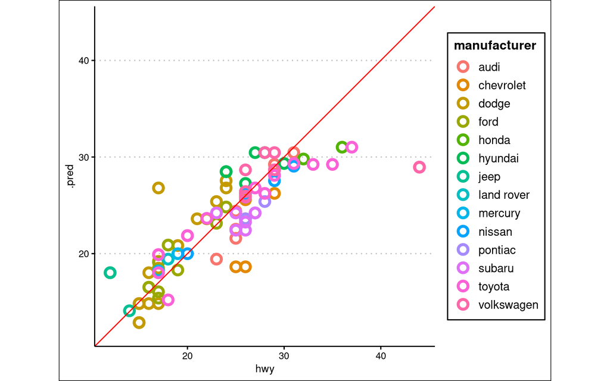

```r
testing_results %>%

    ggplot(mapping = aes(x = hwy, y = .pred, col = manufacturer)) +

    geom_point(shape = 1, size = 3, stroke = 2) +

    geom_abline(col = "red") +

    coord_obs_pred() +

    ggthemes::theme_clean()
```

The root mean squared error is 3.4725706.

```r
testing_results %>%
rmse(truth = hwy, estimate = .pred) %>%
    knitr::kable()
```

| .metric | .estimator | .estimate |
| --- | --- | --- |
| rmse | standard | 3.472571 |

While the `coefficient of determination` is 0.7090558.

```r
testing_results %>%
rsq(truth = hwy, estimate = .pred) %>%
    knitr::kable()
```

| .metric | .estimator | .estimate |
| --- | --- | --- |
| rsq | standard | 0.7090558 |

## Advanced Model Evaluation

The `last_fit` function of the `yardstick` package takes in the recipe, the model and the split object and does the following.

- Splits the data into test and train.
- Runs the model on the training set.
- Runs predictions on the test set.
- Produces model performance metrics using yardstick.

```r
## We do the last fit that is much easier to work with
model_last_fit <- linear_model %>%

  last_fit(hwy ~ displ + factor(year) + factor(drv), split = mpg_split)

## Get model evaluation metrics
model_last_fit %>%

  collect_metrics() %>%

  knitr::kable()
```

| .metric | .estimator | .estimate | .config |
| --- | --- | --- | --- |
| rmse | standard | 3.4725706 | Preprocessor1_Model1 |
| rsq | standard | 0.7090558 | Preprocessor1_Model1 |

```r
## Model predictions
model_last_fit %>%

  collect_predictions() %>%

  knitr::kable()
```

| id | .pred | .row | hwy | .config |
| --- | --- | --- | --- | --- |
| train/test split | 29.23307 | 1 | 29 | Preprocessor1_Model1 |
| train/test split | 29.23307 | 2 | 29 | Preprocessor1_Model1 |
| train/test split | 30.45629 | 3 | 31 | Preprocessor1_Model1 |
| train/test split | 26.41946 | 5 | 26 | Preprocessor1_Model1 |
| train/test split | 24.39730 | 9 | 25 | Preprocessor1_Model1 |
| train/test split | 21.58368 | 13 | 25 | Preprocessor1_Model1 |
| train/test split | 22.52553 | 17 | 25 | Preprocessor1_Model1 |
| train/test split | 19.43055 | 18 | 23 | Preprocessor1_Model1 |
| train/test split | 18.25679 | 22 | 17 | Preprocessor1_Model1 |
| train/test split | 19.19864 | 23 | 17 | Preprocessor1_Model1 |
| train/test split | 18.63592 | 26 | 26 | Preprocessor1_Model1 |
| train/test split | 18.63592 | 27 | 25 | Preprocessor1_Model1 |
| train/test split | 25.57537 | 35 | 26 | Preprocessor1_Model1 |
| train/test split | 26.23586 | 36 | 29 | Preprocessor1_Model1 |
| train/test split | 27.54490 | 38 | 24 | Preprocessor1_Model1 |
| train/test split | 26.79859 | 42 | 24 | Preprocessor1_Model1 |
| train/test split | 26.79859 | 44 | 17 | Preprocessor1_Model1 |
| train/test split | 23.60584 | 45 | 22 | Preprocessor1_Model1 |
| train/test split | 23.60584 | 46 | 21 | Preprocessor1_Model1 |
| train/test split | 25.39178 | 47 | 23 | Preprocessor1_Model1 |
| train/test split | 20.83736 | 49 | 19 | Preprocessor1_Model1 |
| train/test split | 18.48870 | 51 | 17 | Preprocessor1_Model1 |
| train/test split | 18.02375 | 55 | 12 | Preprocessor1_Model1 |
| train/test split | 14.83100 | 56 | 17 | Preprocessor1_Model1 |
| train/test split | 14.83100 | 57 | 15 | Preprocessor1_Model1 |
| train/test split | 18.48870 | 58 | 17 | Preprocessor1_Model1 |
| train/test split | 18.02375 | 59 | 17 | Preprocessor1_Model1 |
| train/test split | 12.86147 | 64 | 15 | Preprocessor1_Model1 |
| train/test split | 18.02375 | 65 | 16 | Preprocessor1_Model1 |
| train/test split | 14.83100 | 71 | 15 | Preprocessor1_Model1 |

[output cut: 66 more lines]